# Interactive Data Vizualisations

26/4/2022

## Topics of the course

1. Start with Interactive Visualization (Highcharts, Plotly & ggplot)
2. Deploy R Code online with Shiny
3. Dashboards
4. Upgrade with HTML, CSS, JS

## Structure

- First Session
  - Introduction to Interactive Stuff
  - Shiny handson Examples & Exercises
  - Discuss Presentations
- Second Sessions
  - Presentations
  - Peek into advanced appliances
  - Further Pointers

## Interactive Data Visualization

- Most popular and best documented frames are Plotly, Highcharts, leaflet
  - all of them are based in JavaScript.
  - luckily you dont need to know JS, as customizing is mostly done in wrappers for various languages (R, Python, …)
  - interactivity needs can only be achieved, where you can run JS. That’s why HTML documents is the Goldstandard
  - There are a ton of ways to share your work

    - ```
      Save your Work as a HTML document (and embed it in your website).
      ```

    - ```
      write in a RMD document and then render to ioslides or slidy (creats also an HTML document)
      ```

    - ```
      write a shiny app and deploy to shinyclouds (or own server)
      ```

- Plotly is the most popular and easiest to work with.
- Highcharts is less known, relatively customizable and free to use in non comercial settings
- leaflet is great for interactive maps

## My first shiny app I

[figure not shown]

## What is Shiny?

> [Shiny](https://shiny.rstudio.com/) is a framework for creating web applications using R code. It is designed primarily with data scientists in mind, and to that end, you can create pretty complicated Shiny apps with no knowledge of HTML, CSS, or JavaScript. On the other hand, Shiny doesn’t limit you to creating trivial or prefabricated apps: its user interface components can be easily customized or extended, and its server uses reactive programming to let you create any type of back end logic you want. Shiny is designed to feel almost magically easy when you’re getting started, and yet the deeper you get into how it works, the more you realize it’s built out of general building blocks that have strong software engineering principles behind them.
> - Hadley Wickham
- Package for creating web-apps

```r
library(shiny)
```

- Gives you easy Framework for deploying interactive R Code to everbody, without learning any other language than R
  - you write the R code and shiny creates the app
  - But if you know some HTML,CSS or JS you can easily utilize this. (easy to learn anyway)
  - interactive app, that takes inputs from the user and updates the outputs accordingly
- Every shiny app consists of three components
  - Userinterface (UI) = The body of your app
  - Server => The brain of your app
  - reactives => The central nervous system of your app

## Shiny Examples

[interactive chart not shown]

## Basic Structure

```r
library(shiny)

ui <- fluidPage(
  "Hello, world!"
)

server <- function(input, output, session) {
}

shinyApp(ui, server)
```

```
##
## Listening on http://127.0.0.1:5421
```

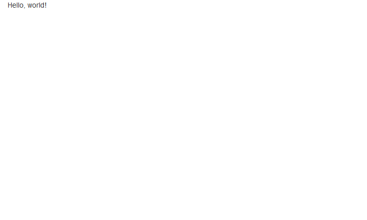

## App Structure

Shiny applications have two components

### UI

User interface for placing and displaying inputs(e.g. scroll bars, buttons) and outputs (e.g. plot)

### Server

Server functions include everything you would normally to do your analysis, but include reactives.

- code your analysis
- connect code to your UI via reactive functions

## Reactives

Reactive functions are something between variables (cold/static) and a function (hot/dynamic) => a function with memory.

First time called: run like a function Second time called: read from cache (if nothing changed)

Example:

```r
library(shiny)
dataset <- reactive({ data(mtcars) })
dataset()
```

Reactives are the magic sprinkles, that deal with the communication between the UI and the Server. Web developers call this concept “callback”. Usually a tedious experience, but shiny manages this almost automatically for you. This is the major USP of shiny (taking care of the dependencies).

## What is Bootstrap?

Bootstrap is a collection of HTML Conventions, CSS Styles, & JavaScript Snippets provided in a convenient form

- originally developed by Twitter, but a popular CSS Frameworks
- also used in R-Package Websites or R Markdown converted HTML
- generated automatically by Shiny - takes HTML Arguments (class, etc. ) in UI
- highly customizable like any website - use themes provided by bs_theme (we’ll look at this later)
- Make your life easier with [bootstraplib](https://www.rdocumentation.org/packages/bootstraplib/versions/0.1.0.9000)
- functions for easy changes in style + an interactive styling app w/ code generator
- it’s possible to use other frameworks than bootstrap
  - see nanxstats/awesome-shiny-extensions for an extensive collection of helpful packages for all kind of topics

## Layout, Themes & HTML

Provides high-level ( high-level = less complex, low-level = more complex) visual structure

Hierarchy of function calls (Waterfall principle + nested)

fluid page, fixed page or fill page —> provides basis HTML and CSS structure (skeleton)

more complex customization need “Layout functions” are nested inside fluidpage

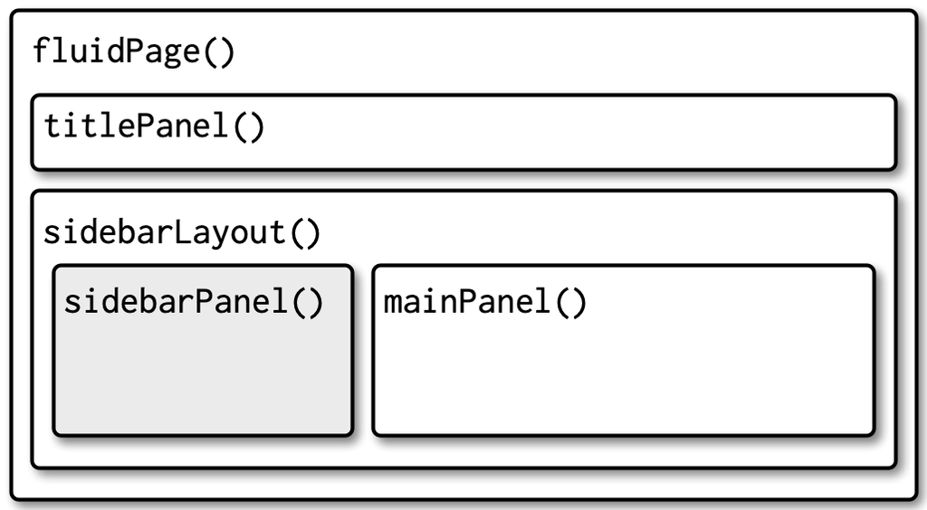

Structure of a basic app with sidebar

## Dashboards

- [shinydashboard](https://rstudio.github.io/shinydashboard/) Maintained by RStudio Developers Team. Well suited for shiny apps.
  - written as shiny app

```r
library(shiny)
library(shinydashboard)
library(shinydashboardPlus) # bonus features.
```

- [flexdashboard](https://pkgs.rstudio.com/flexdashboard/index.html) if you only want to run RMD Documents or if you want to mix content like this dashboard. But its also possible to run shiny by adding **runtime: shiny** to YAML
  - written in a RMD document

```r
-------------------------------------------
title: "Interactive Data Vizualisations"
runtime: shiny
-------------------------------------------
```

## Ressources

[Mastering Shiny Build interactive Apps, Reports & Dashboards Powered by R](https://mastering-shiny.org)

- Very good guide for basic & advanced mechanics of shiny by Hadley Wickham (Tidyverse Guy)

Shiny cheatsheet, available from https://www.rstudio.com/resources/cheatsheets/

[figure not shown]

## Second Session

## Advanced Topics and pointers

- HTML, CSS, JavaScript

## Reactive expressions

eventReactive minimize dependencies Render –> for looks/output observe –> for sideffects( downloadhandler, read data from disc, ….)

observeEvent = observe({x, isolate(y)}) decouples from listening to action

## Deploying your App to the Web

1. Go to https://www.shinyapps.io and create an account or log in with Google/GitHub
2. Follow the instructions for connecting your machine to the server.
3. Publish!

## Pointers I

[ShinyWidgets](http://shinyapps.dreamrs.fr/shinyWidgets/)

## Pointers II

- Once you are familiar with Shiny it’s easy to reuse your know how to create interactive helper for R https://shiny.rstudio.com/articles/gadgets.html
- [Harvard Lecture](https://www.youtube.com/watch?v=zFZrkCIc2Oc) on YouTube, check out the first lecture for a good introduction to those topics.
- Some Android apps to learn HTML, CSS, JavaScript
  - https://play.google.com/store/apps/details?id=com.codeliber.html
  - https://play.google.com/store/apps/details?id=com.codeliber.css
  - https://play.google.com/store/apps/details?id=com.codeliber.js